# 001 Time series

The purpose of this notebook is to evaluate the time series of quotations from the prototype version of America’s Public Bible and create some visualizations of them.

```r
library(xts)
```

What is the difference between the full `quotations` table and the `verses_by_year` table?

```r
quotations_count <- quotations %>%
  group_by(year, reference) %>%
  summarize(full_count = n()) %>%
  mutate(reference = str_remove(reference, " (KJV)")) %>%
  left_join(verses_by_year, by = c("reference", "year"))
```

By joining them it becomes apparent that the verses by year is a subset of the data. How small a subset?

```r
quotations_count_totals <- quotations_count %>%
  group_by(reference) %>%
  summarize(n = sum(n, na.rm = TRUE),
            full_count = sum(full_count, na.rm = TRUE)) %>%
  arrange(desc(n))
quotations_count_totals %>% head(10)
```

| reference | n | full_count |
| --- | --- | --- |
| Luke 18:16 | 5015 | 4915 |
| Exodus 20:15 | 3803 | 4043 |
| Matthew 7:20 | 3330 | 3813 |
| Matthew 25:21 | 3159 | 3603 |
| Exodus 20:13 | 2752 | 3070 |
| Acts 20:35 | 2728 | 2896 |
| Matthew 6:11 | 2545 | 2779 |
| Luke 2:14 | 2481 | 2670 |
| Matthew 25:23 | 2464 | 2665 |
| 1 Thessalonians 5:21 | 2390 | 2540 |

The verses by year have the cleaned data, for example, Luke 18:16 includes the other verses in the Synoptics. But it also has fewer quotations in places, probably because it uses higher probability verses.

```r
range(quotations_count_totals %>% filter(n > 0) %>% pull(n))
```

```
[1]   61 5015
```

```r
range(quotations_count_totals$full_count)
```

```
[1]    1 4915
```

```r
range(quotations$year)
```

```
[1] 1836 1922
```

```r
range(verses_by_year$year)
```

```
[1] 1836 1922
```

```r
range(quotations$probability)
```

```
[1] 0.5000064 0.9999779
```

We are going to use the direct quotations table.

We need to combine some quotations:

```r
combine_verses <- function(.data, references) {
  stopifnot(is.character(references))
  new_ref <- paste0(references[1])
  .data %>%
    mutate(reference = ifelse(reference %in% references, new_ref, reference),
           multiple_references = ifelse(reference %in% references,
                                        paste(references, collapse = ", "),
                                        multiple_references)) %>%
    distinct(page, reference, .keep_all = TRUE)
}
# Taken from _scripts/_clean-data.R in public-bible-website
quotations <- quotations %>%
  mutate(multiple_references = NA_character_) %>%
  combine_verses(c("Luke 18:16 (KJV)",
                   "Mark 10:14 (KJV)",
                   "Matthew 19:14 (KJV)")) %>%  # Suffer the little children
  combine_verses(c("Exodus 20:13 (KJV)",
                   "Deuteronomy 5:17 (KJV)")) %>% # Thou shalt not kill
  combine_verses(c("Matthew 20:28 (KJV)",
                   "Mark 10:45 (KJV)")) %>% # Not to be ministered unto
  combine_verses(c("Jeremiah 8:11 (KJV)",
                 "Jeremiah 6:14 (KJV)")) %>% # Peace, peace, there is no peace
  combine_verses(c("Matthew 24:35 (KJV)",
                 "Mark 13:31 (KJV)",
                 "Luke 21:33 (KJV)")) %>% # My words shall not pass away
  combine_verses(c("Matthew 22:21 (KJV)",
                 "Luke 20:25 (KJV)")) %>% # Render unto Ceasar
  combine_verses(c("Mark 9:44 (KJV)",
                   "Mark 9:46 (KJV)",
                   "Mark 9:48 (KJV)")) %>% # Worm dieth not
  combine_verses(c("Luke 13:3 (KJV)",
                   "Luke 13:5 (KJV)")) %>% # Except yet repent
  combine_verses(c("Psalm 107:8 (KJV)",
                   "Psalm 107:15 (KJV)",
                   "Psalm 107:21 (KJV)",
                   "Psalm 107:31 (KJV)")) %>%
  combine_verses(c("Psalm 46:7 (KJV)",
                   "Psalm 46:11 (KJV)")) %>%
  combine_verses(c("Psalm 67:3 (KJV)",
                   "Psalm 67:5 (KJV)")) %>%
  combine_verses(c("Psalm 107:1 (KJV)",
                   "Psalm 118:29 (KJV)",
                   "Psalm 136:1 (KJV)")) %>%
  combine_verses(c("Matthew 16:26 (KJV)",
                   "Mark 8:36 (KJV)")) %>%
  combine_verses(c("Matthew 19:6 (KJV)",
                   "Mark 10:9 (KJV)")) %>%
  combine_verses(c("John 3:16 (KJV)",
                   "John 3:15 (KJV)")) %>%
  combine_verses(c("Matthew 25:21 (KJV)", # Well done, good and faithful servant
                   "Matthew 25:23 (KJV)")) %>%
  combine_verses(c("Matthew 22:37 (KJV)", # Thou shalt love the Lord thy God
                   "Mark 12:30 (KJV)",
                   "Luke 10:27 (KJV)")) %>%
  combine_verses(c("Matthew 12:25 (KJV)", # House divided
                   "Mark 3:25 (KJV)",
                   "Luke 11:17 (KJV)")) %>%
  combine_verses(c("Matthew 10:25 (KJV)", # Camel eye of a needle
                   "Mark 19:24 (KJV)",
                   "Luke 18:25 (KJV)")) %>%
  combine_verses(c("Matthew 16:23 (KJV)", # Get behind me, Satan
                   "Mark 8:33 (KJV)")) %>%
  filter(reference != "Psalm 107:3 (KJV)") %>% # East, west, north, south
  filter(reference != "Acts 19:7 (KJV)") %>% # And all the men were about twelve
  filter(reference != "1 Chronicles 9:24 (KJV)") %>%  # East west north south
  filter(reference != "Luke 13:29 (KJV)") %>% # East west north south
  filter(reference != "Ezekiel 44:25 (KJV)") # Father mother brother sister
```

Now we are going to aggregate the verse counts by year and get the word and page counts as well.

```r
quotations_per_year <- quotations %>%
  mutate(reference = str_remove(reference, "\\s\\(KJV\\)")) %>%
  count(reference, year, testament) %>%
  group_by(reference) %>%
  mutate(n_all = sum(n)) %>%
  left_join(wordcounts, by = "year") %>%
  mutate(n_per_100mil = n / wordcount * 1e8) %>%
  mutate(smoothed_rate3 = roll_mean(n_per_100mil, n = 3, fill = NA_real_)) %>%
  mutate(smoothed_rate5 = roll_mean(n_per_100mil, n = 5, fill = NA_real_)) %>%
  mutate(change = (smoothed_rate3 - lag(smoothed_rate3)) / smoothed_rate3) %>%
  mutate(smoothed_change3 = roll_mean(change, n = 7, fill = NA_real_)) %>%
  mutate(smoothed_change7 = roll_mean(change, n = 7, fill = NA_real_)) %>%
  arrange(desc(n_all), reference, year) %>%
  filter(year >= 1838) # Cut off some outliers
quotations_per_year %>% head(10)
```

| reference | year | testament | n | n_all | wordcount | pages | n_per_100mil | smoothed_rate3 | smoothed_rate5 | change | smoothed_change3 | smoothed_change7 |
| --- | --- | --- | --- | --- | --- | --- | --- | --- | --- | --- | --- | --- |
| Luke 18:16 | 1839 | NT | 5 | 5015 | 55907791 | 8131 | 8.943297 | 7.149671 | 9.104819 | -0.42835122 | NA | NA |
| Luke 18:16 | 1840 | NT | 4 | 5015 | 63650037 | 9389 | 6.284364 | 7.943555 | 8.067406 | 0.09994062 | NA | NA |
| Luke 18:16 | 1841 | NT | 5 | 5015 | 58119232 | 8423 | 8.603004 | 8.390793 | 7.603143 | 0.05330107 | NA | NA |
| Luke 18:16 | 1842 | NT | 8 | 5015 | 77783087 | 10459 | 10.285012 | 7.596017 | 8.031257 | -0.10463063 | -0.019878412 | -0.019878412 |
| Luke 18:16 | 1843 | NT | 3 | 5015 | 76922372 | 10346 | 3.900036 | 8.422973 | 8.244933 | 0.09817858 | 0.034338724 | 0.034338724 |
| Luke 18:16 | 1844 | NT | 11 | 5015 | 99243308 | 13178 | 11.083871 | 7.445549 | 8.987721 | -0.13127620 | 0.026896982 | 0.026896982 |
| Luke 18:16 | 1845 | NT | 8 | 5015 | 108802950 | 13747 | 7.352742 | 10.251185 | 8.861129 | 0.27368890 | 0.008857975 | 0.008857975 |
| Luke 18:16 | 1846 | NT | 14 | 5015 | 113664572 | 14720 | 12.316943 | 9.773912 | 9.846371 | -0.04883127 | -0.012929810 | -0.012929810 |
| Luke 18:16 | 1847 | NT | 10 | 5015 | 103604901 | 13027 | 9.652053 | 10.265080 | 9.674113 | 0.04784842 | -0.033629974 | -0.033629974 |
| Luke 18:16 | 1848 | NT | 10 | 5015 | 113298457 | 14397 | 8.826246 | 9.566960 | 8.959840 | -0.07297198 | -0.018937952 | -0.018937952 |

Now we can try to plot the time series for the most frequently quoted verses.

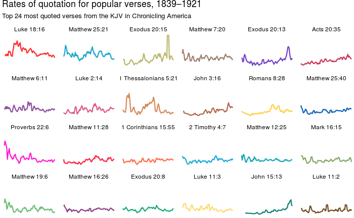

```r
top_verses <- quotations_per_year %>%
  ungroup() %>%
  distinct(reference, n_all) %>%
  top_n(24, n_all)
verse_order <- top_verses %>% pull(reference)
# See broman::plot_crayons()
set.seed(97)
col_pal <- brocolors("crayons")[c("Orange Red", "Outrageous Orange", "Brown",
                                  "Beaver", "Raw Sienna", "Raw Umber", "Sunglow",
                                  "Goldenrod", "Asparagus", "Fern", "Green",
                                  "Pine Green", "Teal Blue", "Pacific Blue",
                                  "Cerulean", "Green Blue", "Purple Heart",
                                  "Vivid Violet", "Hot Magenta", "Maroon",
                                  "Scarlet", "Olive Green", "Blush", "Plum")] %>%
  sample()
names(col_pal) <- verse_order
# Smooth the charts by taking the mean
quotations_per_year %>%
  ungroup() %>%
  inner_join(select(top_verses, reference), by = "reference") %>%
  mutate(reference = ordered(reference, verse_order)) %>%
  arrange(reference, year) %>%
  filter(!is.na(smoothed_rate3)) %>%
  ggplot(aes(x = year, y = smoothed_rate3, color = reference)) +
  geom_line(size = 0.8) +
  facet_wrap(~reference, ncol = 6) +
  coord_cartesian(ylim = c(0, 20)) +
  guides(color = FALSE) +
  theme_void() +
  scale_color_manual(values = col_pal) +
  labs(title = "Rates of quotation for popular verses, 1839–1921",
       subtitle = "Top 24 most quoted verses from the KJV in Chronicling America")
ggsave("tsclusters/top-24-verses.png")
```

Now can we cluster the time series? The choice of the variable for clustering is important. If we pick `smoothed_rate` we are looking for verses which had the same popularity at the same time. If we pick `smoothed_change` we are clustering by the change over time, and so are looking for verses with the same shape to their line.

```r
top_100_verses <- quotations_per_year %>%
  ungroup() %>%
  distinct(reference, n_all) %>%
  top_n(100, n_all)
year_to_date <- function(y) { as.Date(paste0(y, "-01-01")) }

ts_df <- quotations_per_year %>%
  ungroup() %>%
  inner_join(select(top_100_verses, reference), by = "reference") %>%
  mutate(date = year_to_date(year)) %>%
  group_by(reference)
ts_df_rate <- ts_df %>%
  select(date, reference, cluster_variable = smoothed_rate5) %>%
  spread(reference, cluster_variable, fill = 0) # Pick the variable for clustering
ts_df_change <- ts_df %>%
  select(date, reference, cluster_variable = smoothed_change7) %>%
  spread(reference, cluster_variable, fill = 0) # Pick the variable for clustering
```

Now we can try to cluster them. We will cluster by both rate and change, though obviously this puts verses in multiple clusters.

```r
create_clusters <- function(ts_df_in, k, prefix) {
  ts <- xts(ts_df_in[, -1], order.by = ts_df_in$date)
  ts_dist <- diss(t(ts), "ACF", p = 0.05)
  names(ts_dist) <- colnames(ts)
  hc <- hclust(ts_dist)
  # plot(hc)
  cluster_groups <- cutree(hc, k = k) %>% tidy()
  cluster_groups %>%
    select(reference = names, cluster = x) %>%
    mutate(cluster = str_c(prefix, str_pad(cluster, 2, "left", "0")))
}
clusters <- bind_rows(
  create_clusters(ts_df_rate, k = 8, prefix = "rate8-"),
  create_clusters(ts_df_change, k = 8, prefix = "change8-")
)
```

Helper functions to plot the clusters.

```r
get_quotes_from_group <- function(.data, groups, group_num) {
  group <- groups %>% filter(cluster == group_num)
  .data %>%
    inner_join(select(group, reference), by = "reference")
}
plot_ts_group <- function(.data, top = 10, title) {
  keepers <- .data %>%
    group_by(reference) %>%
    summarize(n = sum(n)) %>%
    arrange(desc(n)) %>%
    top_n(top, n)
  verses <- keepers %>% pull(reference) %>% unique()
  selected <- .data %>%
    inner_join(select(keepers, reference), by = "reference") %>%
    filter(!is.na(smoothed_rate5))
  years <- range(selected$year) %>% str_c(collapse = "–")
  ggplot(selected, aes(x = year, y = smoothed_rate5, color = reference)) +
    geom_line() +
    scale_color_viridis(discrete = TRUE) +
    theme_minimal() +
    theme(legend.position = "bottom") +
    labs(title = title,
         subtitle = str_glue("Select verses from the KJV in Chronicling America, {years}"),
         color = NULL, x = NULL,
         y = "Quotations per 100 million words")
}
```

Keep certain charts.

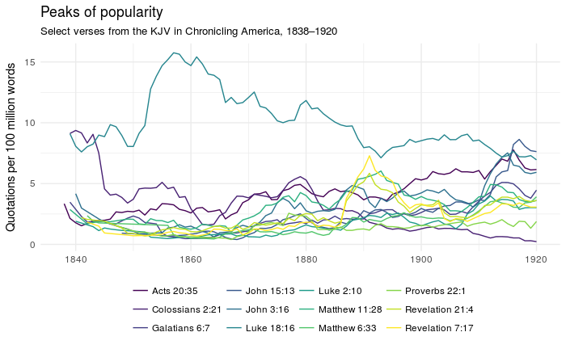

```r
selector <- "rate8-08"
title <- "Peaks of popularity"
plot <- quotations_per_year %>%
  get_quotes_from_group(clusters, selector) %>%
  plot_ts_group(top = 20, title = title)
plot
```

```r
# ggsave(str_glue("tsclusters/{selector}.png"), plot)
```